# Data manipulation and pipes

Statistical Programming with R

## This lecture

- Data manipulation
- Basic analysis (correlation & t-test)
- R model formula and classes
- Pipes

## New packages we use

```r
library(MASS)     # for the cats data
library(dplyr)    # data manipulation
library(haven)    # in/exporting data
library(magrittr) # pipes
```

[figure not shown]

[figure not shown]

## New functions

- `transform()`: changing and adding columns
- `dplyr::filter()`: row-wise selection (of cases)
- `dplyr::arrange()`: order rows by values of a column or columns (low to high)
- `table()`: frequency tables
- `class()`: object class
- `levels()`: levels of a factor
- `order()`: data entries in increasing order
- `haven::read_sav()`: import SPSS data
- `cor()`: bivariate correlation
- `sample()`: drawing a sample
- `t.test()`: t-test

## Data manipulation

## The cats data

Description (see `?cats`): The heart weights (in g) and body weights (in kg) of 144 adult cats (male and female) used for digitalis experiments. Digitalis is a medication used to treat heart failure and certain types of irregular heartbeat.

```r
head(cats)
```

```
##   Sex Bwt Hwt
## 1   F 2.0 7.0
## 2   F 2.0 7.4
## 3   F 2.0 9.5
## 4   F 2.1 7.2
## 5   F 2.1 7.3
## 6   F 2.1 7.6
```

```r
str(cats)
```

```
## 'data.frame':    144 obs. of  3 variables:
##  $ Sex: Factor w/ 2 levels "F","M": 1 1 1 1 1 1 1 1 1 1 ...
##  $ Bwt: num  2 2 2 2.1 2.1 2.1 2.1 2.1 2.1 2.1 ...
##  $ Hwt: num  7 7.4 9.5 7.2 7.3 7.6 8.1 8.2 8.3 8.5 ...
```

## The cats data

```r
summary(cats)
```

```
##  Sex         Bwt             Hwt
##  F:47   Min.   :2.000   Min.   : 6.30
##  M:97   1st Qu.:2.300   1st Qu.: 8.95
##         Median :2.700   Median :10.10
##         Mean   :2.724   Mean   :10.63
##         3rd Qu.:3.025   3rd Qu.:12.12
##         Max.   :3.900   Max.   :20.50
```

## How to get only Female cats?

```r
# With dplyr::filter
fem.cats <- dplyr::filter(cats, Sex == "F")

dim(fem.cats)
```

```
## [1] 47  3
```

```r
# With base R:
# fem.cats <- cats[cats$Sex == "F", ]
```

## How to get only *heavy* cats?

```r
heavy.cats <- dplyr::filter(cats, Bwt > 3)
dim(heavy.cats)
```

```
## [1] 36  3
```

```r
head(heavy.cats)
```

```
##   Sex Bwt  Hwt
## 1   M 3.1  9.9
## 2   M 3.1 11.5
## 3   M 3.1 12.1
## 4   M 3.1 12.5
## 5   M 3.1 13.0
## 6   M 3.1 14.3
```

```r
# With base R:
# heavy.cats2 <- cats[cats$Bwt > 3, ]
# or:
# heavy.cats3 <- subset(cats, Bwt > 3)
```

## Select cats with specified range of body weights

```r
dplyr::filter(cats, Bwt > 2.0 & Bwt < 2.2, Sex == "F")
```

```
##   Sex Bwt Hwt
## 1   F 2.1 7.2
## 2   F 2.1 7.3
## 3   F 2.1 7.6
## 4   F 2.1 8.1
## 5   F 2.1 8.2
## 6   F 2.1 8.3
## 7   F 2.1 8.5
## 8   F 2.1 8.7
## 9   F 2.1 9.8
```

## Working with factors

```r
class(cats$Sex)
```

```
## [1] "factor"
```

```r
levels(cats$Sex)
```

```
## [1] "F" "M"
```

## Working with factors

Changing the level names:

```r
levels(cats$Sex) <- c("Female", "Male")

table(cats$Sex)
```

```
##
## Female   Male
##     47     97
```

```r
head(cats)
```

```
##      Sex Bwt Hwt
## 1 Female 2.0 7.0
## 2 Female 2.0 7.4
## 3 Female 2.0 9.5
## 4 Female 2.1 7.2
## 5 Female 2.1 7.3
## 6 Female 2.1 7.6
```

## Sorting with `dplyr::arrange()`

`dplyr::arrange()`sorts the rows of a data frame according to the order of one or more of the columns.

```r
# sort cats by body weight (Bwt) from low to high values
sorted.cats <- dplyr::arrange(cats, Bwt)
head(sorted.cats)
```

```
##      Sex Bwt Hwt
## 1 Female 2.0 7.0
## 2 Female 2.0 7.4
## 3 Female 2.0 9.5
## 4   Male 2.0 6.5
## 5   Male 2.0 6.5
## 6 Female 2.1 7.2
```

## Sorting with `dplyr::arrange()`

`dplyr::arrange()`sorts the rows of a data frame according to the order of one or more of the columns.

```r
# Sort the cats by Sex first and within Sex (1=female) by body weight (low to high)
sorted.cats.grouped <- dplyr::arrange(cats, Sex, Bwt)
head(sorted.cats.grouped)
```

```
##      Sex Bwt Hwt
## 1 Female 2.0 7.0
## 2 Female 2.0 7.4
## 3 Female 2.0 9.5
## 4 Female 2.1 7.2
## 5 Female 2.1 7.3
## 6 Female 2.1 7.6
```

## Combining matrices or dataframes

```r
# add column with id numbers
ID <- matrix(c(1:144), nrow=144, ncol=1)
```

```r
# add variable name for ID variable and change names of other variables
D <- dplyr::bind_cols(ID, cats)
names(D) <- c("ID", "Sex", "Bodyweigt", "Hartweight")
head(D)
```

```
##   ID    Sex Bodyweigt Hartweight
## 1  1 Female       2.0        7.0
## 2  2 Female       2.0        7.4
## 3  3 Female       2.0        9.5
## 4  4 Female       2.1        7.2
## 5  5 Female       2.1        7.3
## 6  6 Female       2.1        7.6
```

## Basic analysis

## Correlation

```r
cor(cats[, -1])
```

```
##           Bwt       Hwt
## Bwt 1.0000000 0.8041274
## Hwt 0.8041274 1.0000000
```

With `[, -1]` we exclude the first column (female/male)

## Correlation

```r
cor.test(cats$Bwt, cats$Hwt)
```

```
##
##  Pearson's product-moment correlation
##
## data:  cats$Bwt and cats$Hwt
## t = 16.119, df = 142, p-value < 2.2e-16
## alternative hypothesis: true correlation is not equal to 0
## 95 percent confidence interval:
##  0.7375682 0.8552122
## sample estimates:
##       cor
## 0.8041274
```

What do we conclude?

## Correlation

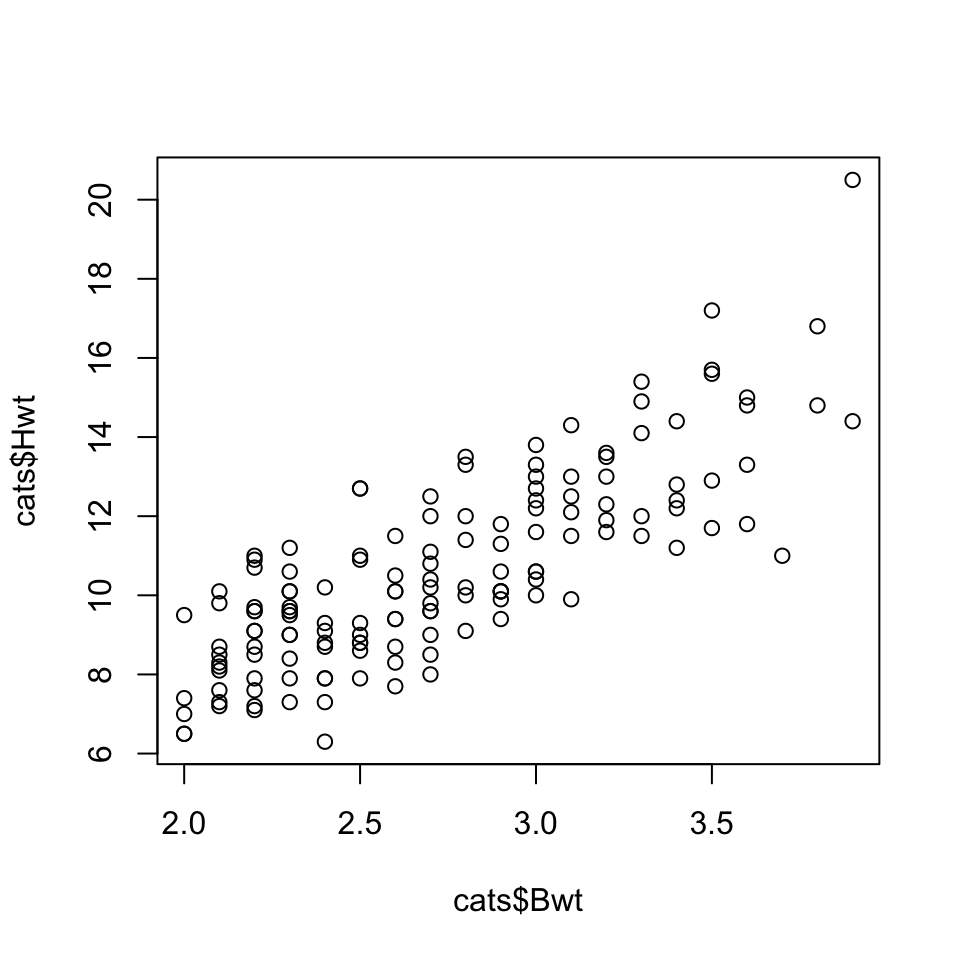

```r
plot(cats$Bwt, cats$Hwt)
```

## T-test

Test the null hypothesis that the difference in mean heart weight between male and female cats is 0

```r
t.test(formula = Hwt ~ Sex, data = cats)
```

```
##
##  Welch Two Sample t-test
##
## data:  Hwt by Sex
## t = -6.5179, df = 140.61, p-value = 1.186e-09
## alternative hypothesis: true difference in means between group Female and group Male is not equal to 0
## 95 percent confidence interval:
##  -2.763753 -1.477352
## sample estimates:
## mean in group Female   mean in group Male
##             9.202128            11.322680
```

## T-test

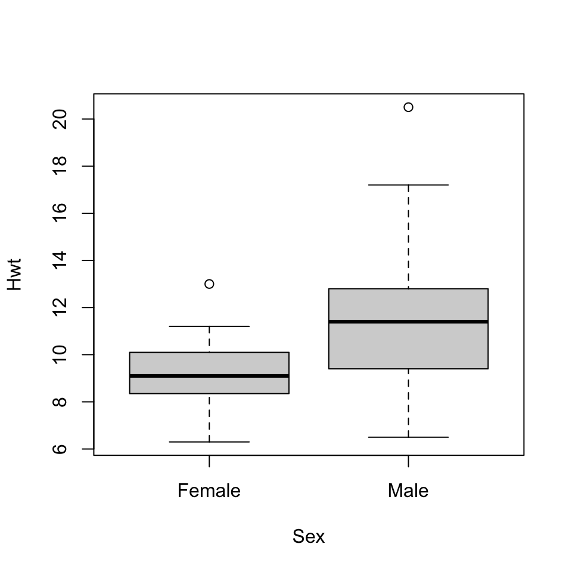

```r
plot(formula = Hwt ~ Sex, data = cats)
```

## Linear regression

Remember the `boys` data from package `mice`.

If we want to regress BMI (`bmi`) on weight (`wgt`), we would use the `lm()` function and the model formula `bmi ~ wgt`.

```r
lm(formula = bmi ~ wgt, data = boys)
```

```
##
## Call:
## lm(formula = bmi ~ wgt, data = boys)
##
## Coefficients:
## (Intercept)          wgt
##     14.5401       0.0935
```

## Scatterplot

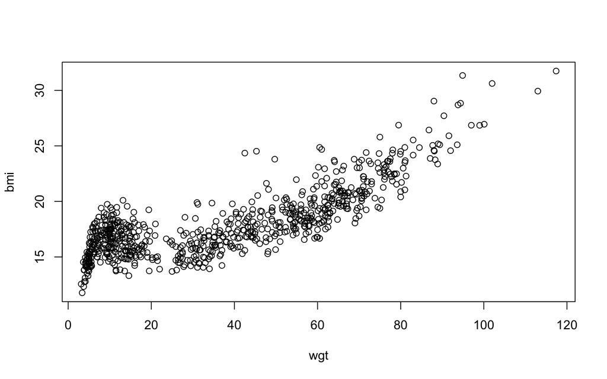

```r
plot(formula = bmi ~ wgt, data = boys)
```

## Add a quadratic term

```r
lm(formula = bmi ~ wgt + I(wgt^2), data = boys)
```

```
##
## Call:
## lm(formula = bmi ~ wgt + I(wgt^2), data = boys)
##
## Coefficients:
## (Intercept)          wgt     I(wgt^2)
##   16.271466    -0.041715     0.001604
```

## Why we need `I()`

Inside an R model formula, the `+`, `:`, and `^` operators are text objects and therefore behave differently than when used in calculations with numeric vectors. Using `I()` converts these operators to their numerical meaning.

```r
lm(bmi ~ wgt + wgt^2, data = boys)
```

```
##
## Call:
## lm(formula = bmi ~ wgt + wgt^2, data = boys)
##
## Coefficients:
## (Intercept)          wgt
##     14.5401       0.0935
```

```r
lm(bmi ~ wgt + I(wgt^2), data = boys)
```

```
##
## Call:
## lm(formula = bmi ~ wgt + I(wgt^2), data = boys)
##
## Coefficients:
## (Intercept)          wgt     I(wgt^2)
##   16.271466    -0.041715     0.001604
```

## Output of the `lm()` class

It is ‘nicer’ to store the output from the function in an object. The convention for regression models is an object called `fit`.

```r
fit <- lm(bmi ~ wgt + I(wgt^2), data = boys)
```

The object `fit` contains a lot more than just the regression weights. To inspect what is inside you can use

```r
ls(fit)
```

```
##  [1] "assign"        "call"          "coefficients"  "df.residual"
##  [5] "effects"       "fitted.values" "model"         "na.action"
##  [9] "qr"            "rank"          "residuals"     "terms"
## [13] "xlevels"
```

## Inspecting what is inside `fit`

Another approach to inspecting the contents of `fit` is the function `attributes()`

```r
attributes(fit)
```

```
## $names
##  [1] "coefficients"  "residuals"     "effects"       "rank"
##  [5] "fitted.values" "assign"        "qr"            "df.residual"
##  [9] "na.action"     "xlevels"       "call"          "terms"
## [13] "model"
##
## $class
## [1] "lm"
```

The benefit of using `attributes()` is that it directly tells you the class of the object.

## Classes in R

```r
class(fit)
```

```
## [1] "lm"
```

Classes are used for an object-oriented style of programming. This means that you can write a specific function that

- has fixed requirements with respect to the input.
- presents output or graphs in a predefined manner.

When a generic function `fun` is applied to an object with class attribute `c("first", "second")`, the system searches for a function called `fun.first` and, if it finds it, applies it to the object.

If no such function is found, a function called `fun.second` is tried. If no class name produces a suitable function, the function `fun.default` is used (if it exists). If there is no class attribute, the implicit class is tried, then the default method.

## Classes example: plotting without class

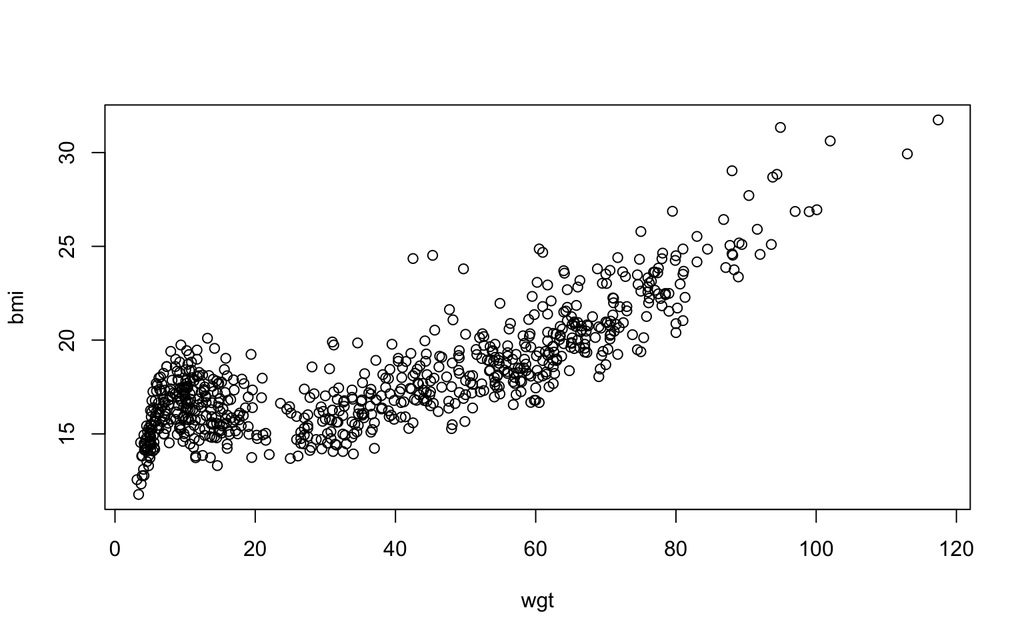

```r
plot(bmi ~ wgt, data = boys)
```

## Classes example: plotting with class

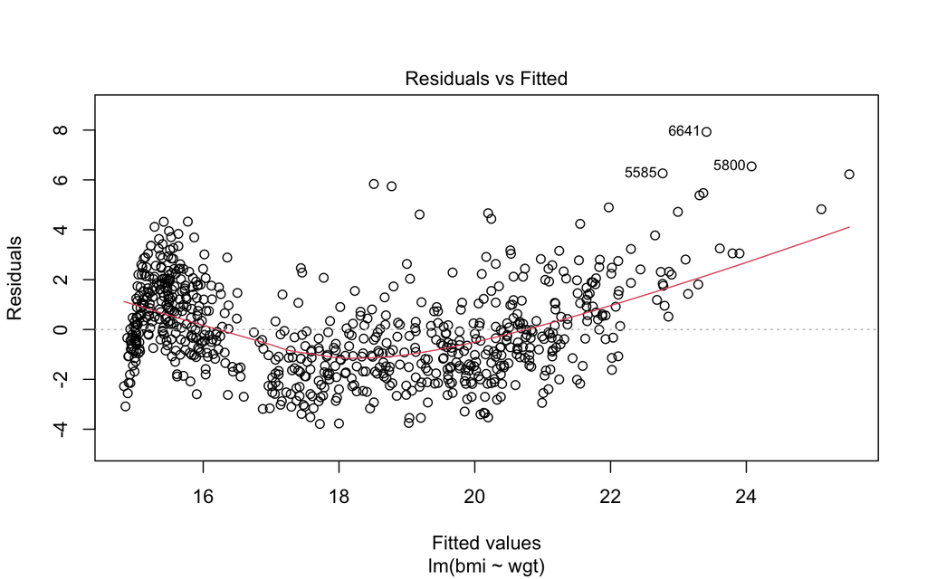

```r
plot(lm(bmi ~ wgt, data = boys), which = 1)
```

## Classes example: plotting with class

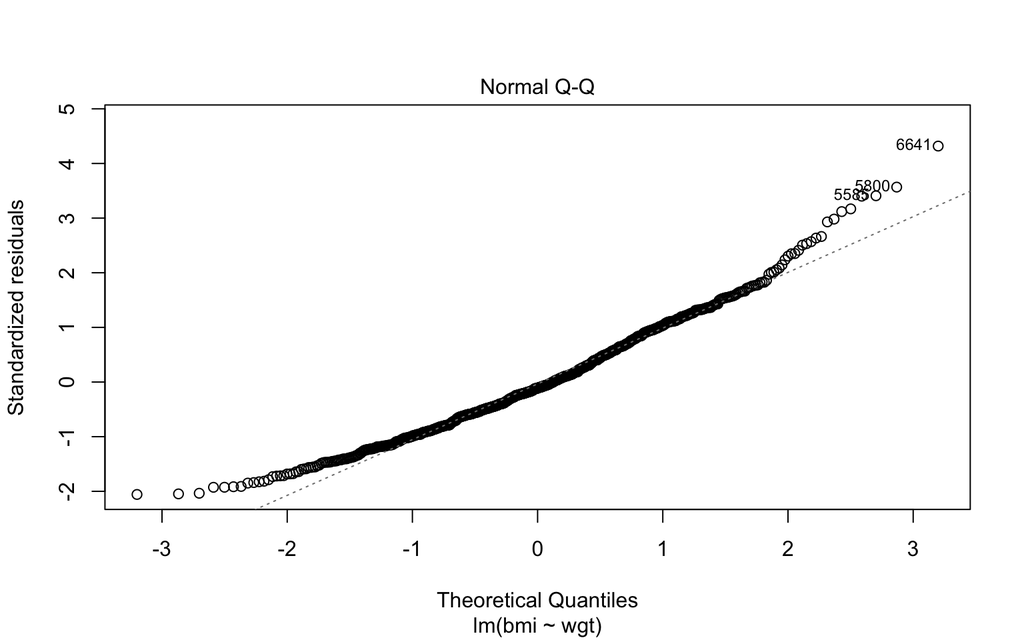

```r
plot(lm(bmi ~ wgt, data = boys), which = 2)
```

## Classes example: plotting with class

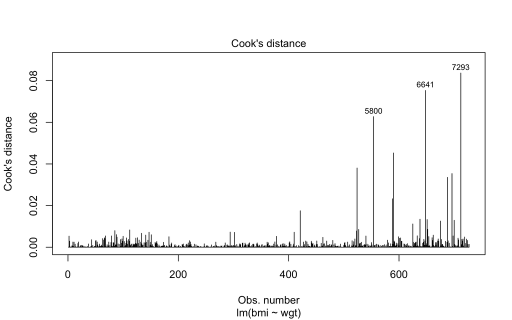

```r
plot(lm(bmi ~ wgt, data = boys), which = 4)
```

## Why is plot different for class `"lm"`?

The function `plot()` is called, but not used. Instead, because the linear model has class `"lm"`, `R` searches for the function `plot.lm()`.

If function `plot.lm()` would not exist, `R` tries to apply function `plot()` (which would have failed in this case because plot requires `x` and `y` as input)

`plot.lm()` is created by John Maindonald and Martin Maechler. They thought it would be useful to have a standard plotting environment for objects with class `"lm"`.

Since the elements that class `"lm"` returns are known, creating a generic function class is straightforward.

## Pipes

## This is a pipe:

```r
boys <-
  read_sav("boys.sav") %>%
  head()
```

It effectively replaces `head(read_sav("boys.sav"))`.

## Why are pipes useful?

Let’s assume that we want to load data, change a variable, filter cases and select columns. Without a pipe, this would look like

```r
boys  <- read_sav("boys.sav")
boys2 <- transform(boys, hgt = hgt / 100)
boys3 <- filter(boys2, age > 15)
boys4 <- subset(boys3, select = c(hgt, wgt, bmi))
```

With the pipe:

```r
boys <-
  read_sav("boys.sav") %>%
  transform(hgt = hgt/100) %>%
  filter(age > 15) %>%
  subset(select = c(hgt, wgt, bmi))
```

Benefit: a single object in memory, the steps are easy to follow and understand.

## With pipes

Your code becomes more readable:

- data operations are structured from left-to-right and not from in-to-out
- nested function calls are avoided
- local variables and copied objects are avoided
- easy to add steps in the sequence

Keyboard shortcut:

- Windows/Linux: `ctrl + shift + m`
- Mac: `cmd + shift + m`

## What do pipes do:

Pipes create functions without nesting:

`f(x)` becomes `x %>% f()`

```r
set.seed(123)
mean(rnorm(10))
```

```
## [1] 0.07462564
```

```r
set.seed(123)
rnorm(10) %>%
  mean()
```

```
## [1] 0.07462564
```

## Pipes create functions without nesting

`f(x, y)` becomes `x %>% f(y)`

```r
cor(boys, use = "pairwise.complete.obs")
```

```
##           hgt       wgt       bmi
## hgt 1.0000000 0.6100784 0.1758781
## wgt 0.6100784 1.0000000 0.8841304
## bmi 0.1758781 0.8841304 1.0000000
```

```r
boys %>%
  cor(use = "pairwise.complete.obs")
```

```
##           hgt       wgt       bmi
## hgt 1.0000000 0.6100784 0.1758781
## wgt 0.6100784 1.0000000 0.8841304
## bmi 0.1758781 0.8841304 1.0000000
```

## Pipes create functions without nesting

`h(g(f(x)))` becomes `x %>% f %>% g %>% h`

```r
max(na.omit(subset(boys, select = wgt)))
```

```
## [1] 117.4
```

```r
boys %>%
  subset(select = wgt) %>%
  na.omit() %>%
  max()
```

```
## [1] 117.4
```

## Useful: outlier filtering

```r
nrow(cats)
```

```
## [1] 144
```

```r
# select the observations that fall outside the +/- SD around the mean
cats.outl <-
  cats %>%
  dplyr::filter(Hwt > mean(Hwt) + 3 * sd(Hwt) | Hwt < mean(Hwt) - 3 * sd(Hwt))

nrow(cats.outl)
```

```
## [1] 1
```

```r
# select the observations that fall within +/- 3 SD around the mean
cats.without.outl <-
  cats %>%
  dplyr::filter(Hwt < mean(Hwt) + 3 * sd(Hwt) & Hwt > mean(Hwt) - 3 * sd(Hwt))

nrow(cats.without.outl)
```

```
## [1] 143
```

## More pipe stuff

## Pipes and the R model formula `~`

Sometimes the data we want to use, are “piped” in the wrong argument, see e.g.:

```r
cats %>%
  lm(Hwt ~ Bwt)
```

This leads to an error:

Error in as.data.frame.default(data) :

cannot coerce class ‘“formula”’ to a data.frame

The `%>%` pipe operator is intended to work with functions where each result is forwarded on to the **first** argument of the next function. For the function `lm()` the first argument is the model formula, which is a text object and not the data frame.

## Solution 1

We can use the `.` symbol to act as placeholder for the data:

```r
cats %>%
  lm(Hwt ~ Bwt, data = .)
```

```
##
## Call:
## lm(formula = Hwt ~ Bwt, data = .)
##
## Coefficients:
## (Intercept)          Bwt
##     -0.3567       4.0341
```

## Solution 2: the exposition `%$%` pipe

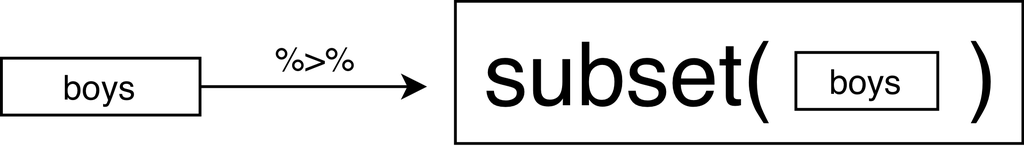

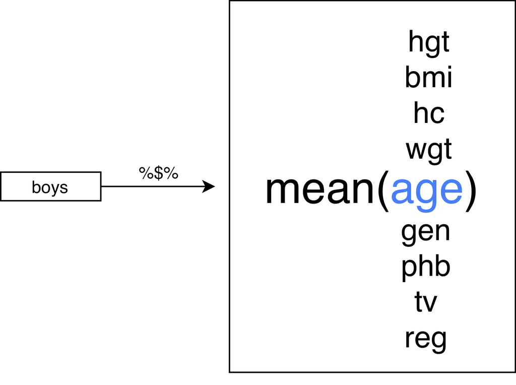

## Solution 2: the exposition `%$%` pipe

The exposition `%$%` pipe exposes the content(s) of the data frame (the variables) to the next function in the pipeline.

```r
# Now the code works without need of the placeholder

cats %$%
  lm(Hwt ~ Bwt)
```

```
##
## Call:
## lm(formula = Hwt ~ Bwt)
##
## Coefficients:
## (Intercept)          Bwt
##     -0.3567       4.0341
```

## Debugging pipelines

Sample 3 positions from the alphabet and show the position and the letter. If you don’t know what’s going on, run each statement separately!

```r
set.seed(123)
1:26
```

```
##  [1]  1  2  3  4  5  6  7  8  9 10 11 12 13 14 15 16 17 18 19 20 21 22 23 24 25
## [26] 26
```

```r
set.seed(123)
1:26 %>%
  sample(3)
```

```
## [1] 15 19 14
```

```r
set.seed(123)
1:26 %>%
  sample(3) %>%
  paste(., LETTERS[.])
```

```
## [1] "15 O" "19 S" "14 N"
```

## Performing a t-test in a pipe

```r
cats %$%
  t.test(Hwt ~ Sex)
```

```
##
##  Welch Two Sample t-test
##
## data:  Hwt by Sex
## t = -6.5179, df = 140.61, p-value = 1.186e-09
## alternative hypothesis: true difference in means between group Female and group Male is not equal to 0
## 95 percent confidence interval:
##  -2.763753 -1.477352
## sample estimates:
## mean in group Female   mean in group Male
##             9.202128            11.322680
```

is the same as

```r
t.test(Hwt ~ Sex, data = cats)
```

## Storing a t-test from a pipe

```r
cats.test <-
  cats %$%
  t.test(Bwt ~ Sex)

cats.test
```

```
##
##  Welch Two Sample t-test
##
## data:  Bwt by Sex
## t = -8.7095, df = 136.84, p-value = 8.831e-15
## alternative hypothesis: true difference in means between group Female and group Male is not equal to 0
## 95 percent confidence interval:
##  -0.6631268 -0.4177242
## sample estimates:
## mean in group Female   mean in group Male
##             2.359574             2.900000
```